En esta NoteBook se pretende ilustrar en cuatro simples gráficos los problemas macroeconómicos de Argentina y cómo eso afecta al empleo en materia de precio (sueldo) y cantidad.

# Librerías

```python
import numpy as np
import pandas as pd
from datetime import datetime

import matplotlib.dates as dates
import matplotlib.pyplot as plt
from prettytable import PrettyTable

import warnings
warnings.filterwarnings("ignore")
```

# Datos

A los fines de poder llevar a cabo los análisis correspondientes los datos fueron descargados manualmente y pasados a formato TXT. Se procedió de esta forma debido a que a algunas de las rutas no se puede acceder directamente desde Python. Por ende, si se desea realizar lo propio desde distintos mecanismos, al pie de los siguientes links se encontrarán los hipervínculos que hay en cada uno de ellos y a partir de los cuales se descargan los datos. Links: - https://data.worldbank.org/indicator/NY.GDP.DEFL.KD.ZG?locations=AR (1) - https://data.worldbank.org/indicator/NY.GDP.MKTP.KD.ZG?locations=AR (2) - https://www.argentina.gob.ar/economia/politicaeconomica/macroeconomica/gastopublicoconsolidado (3) - https://www.trabajo.gov.ar/downloads/estadisticas/trabajoregistrado/trabajoregistrado_2203_estadisticas.xlsx - https://datos.gob.ar/ar/dataset/sspm-asalariados-registrados-sector-privado-por-provincia/archivo/sspm_154.1 (4) - https://www.indec.gob.ar/indec/web/Nivel4-Tema-4-31-61 (5)(6) - https://www.indec.gob.ar/indec/web/Nivel4-Tema-3-9-48 (7) 1. datos: inflación desde 1960. formato: CSV. 2. datos: PBI desde 1960. formato: CSV. 3. datos: Gasto público consolidado desde 1980. formato: XLS. 4. DESCARGAR (fondo verde y letras blancas en mayúscula). formato: XLSX. 5. Índice de salarios. Números índices y variaciones porcentuales respecto del período anterior y acumuladas, por sector. Octubre de 2015-abril de 2022 6. Índice de salarios, valores al último día de cada mes, desde octubre de 2001 en adelante (empalme de la serie base cuarto trimestre de 2001=100 con la serie base abril de 2012=100) 7. Estimador mensual de actividad económica, base 2004. Números índice (base 2004=100) y variaciones porcentuales. Años 2004-2022

### Trabajo por Provincia desde 2009

```python
n_jobs_per_province = pd.read_csv("empleoProv.txt", sep='\t') # employment since 2009
print("raw data".title())
display(n_jobs_per_province.head())

n_jobs_per_province['total'] = n_jobs_per_province[n_jobs_per_province.select_dtypes("number").columns].sum(axis = 1)
n_jobs_per_province['indice_tiempo'] = pd.to_datetime(n_jobs_per_province['indice_tiempo'])
n_jobs_per_province.set_index('indice_tiempo', inplace = True)

print("\nprocessed data".title())
display(n_jobs_per_province.head())
```

```
Raw Data
```

|  | indice_tiempo | asalariados_priv_buenos_aires | asalariados_priv_caba | asalariados_priv_catamarca | asalariados_priv_chaco | asalariados_priv_chubut | asalariados_priv_cordoba | asalariados_priv_corrientes | asalariados_priv_entre_rios | asalariados_priv_formosa | ... | asalariados_priv_neuquen | asalariados_priv_rio_negro | asalariados_priv_salta | asalariados_priv_san_juan | asalariados_priv_san_luis | asalariados_priv_santa_cruz | asalariados_priv_santa_fe | asalariados_priv_santiago_estero | asalariados_priv_tierra_fuego | asalariados_priv_tucuman |
| --- | --- | --- | --- | --- | --- | --- | --- | --- | --- | --- | --- | --- | --- | --- | --- | --- | --- | --- | --- | --- | --- |
| 0 | 2009-01-01 | 1787.640 | 1469.941 | 29.789 | 59.917 | 93.274 | 457.589 | 63.403 | 118.240 | 20.594 | ... | 92.927 | 109.325 | 100.327 | 73.954 | 52.385 | 54.735 | 459.325 | 41.929 | 27.006 | 129.765 |
| 1 | 2009-02-01 | 1769.223 | 1467.029 | 30.504 | 60.212 | 92.852 | 456.084 | 63.791 | 118.017 | 20.837 | ... | 93.316 | 111.229 | 100.914 | 74.532 | 51.639 | 55.166 | 453.637 | 41.987 | 26.465 | 130.383 |
| 2 | 2009-03-01 | 1745.913 | 1466.167 | 31.819 | 61.331 | 93.235 | 454.039 | 64.836 | 119.666 | 20.947 | ... | 91.581 | 107.136 | 100.215 | 76.425 | 51.528 | 54.718 | 454.632 | 42.328 | 26.185 | 137.924 |
| 3 | 2009-04-01 | 1729.917 | 1454.724 | 31.261 | 61.796 | 91.650 | 451.044 | 64.309 | 119.799 | 20.963 | ... | 87.304 | 93.602 | 97.142 | 74.261 | 51.046 | 53.979 | 452.583 | 42.547 | 25.744 | 149.951 |
| 4 | 2009-05-01 | 1723.218 | 1451.374 | 30.366 | 62.265 | 90.353 | 447.114 | 64.257 | 120.941 | 21.130 | ... | 85.173 | 88.599 | 98.239 | 72.668 | 50.783 | 52.941 | 449.091 | 42.505 | 25.276 | 155.374 |

5 rows × 25 columns

```
Processed Data
```

| indice_tiempo | asalariados_priv_buenos_aires | asalariados_priv_caba | asalariados_priv_catamarca | asalariados_priv_chaco | asalariados_priv_chubut | asalariados_priv_cordoba | asalariados_priv_corrientes | asalariados_priv_entre_rios | asalariados_priv_formosa | asalariados_priv_jujuy | ... | asalariados_priv_rio_negro | asalariados_priv_salta | asalariados_priv_san_juan | asalariados_priv_san_luis | asalariados_priv_santa_cruz | asalariados_priv_santa_fe | asalariados_priv_santiago_estero | asalariados_priv_tierra_fuego | asalariados_priv_tucuman | total |
| --- | --- | --- | --- | --- | --- | --- | --- | --- | --- | --- | --- | --- | --- | --- | --- | --- | --- | --- | --- | --- | --- |
| 2009-01-01 | 1787.640 | 1469.941 | 29.789 | 59.917 | 93.274 | 457.589 | 63.403 | 118.240 | 20.594 | 50.544 | ... | 109.325 | 100.327 | 73.954 | 52.385 | 54.735 | 459.325 | 41.929 | 27.006 | 129.765 | 5659.961 |
| 2009-02-01 | 1769.223 | 1467.029 | 30.504 | 60.212 | 92.852 | 456.084 | 63.791 | 118.017 | 20.837 | 50.327 | ... | 111.229 | 100.914 | 74.532 | 51.639 | 55.166 | 453.637 | 41.987 | 26.465 | 130.383 | 5647.381 |
| 2009-03-01 | 1745.913 | 1466.167 | 31.819 | 61.331 | 93.235 | 454.039 | 64.836 | 119.666 | 20.947 | 47.760 | ... | 107.136 | 100.215 | 76.425 | 51.528 | 54.718 | 454.632 | 42.328 | 26.185 | 137.924 | 5634.862 |
| 2009-04-01 | 1729.917 | 1454.724 | 31.261 | 61.796 | 91.650 | 451.044 | 64.309 | 119.799 | 20.963 | 45.805 | ... | 93.602 | 97.142 | 74.261 | 51.046 | 53.979 | 452.583 | 42.547 | 25.744 | 149.951 | 5576.559 |
| 2009-05-01 | 1723.218 | 1451.374 | 30.366 | 62.265 | 90.353 | 447.114 | 64.257 | 120.941 | 21.130 | 47.167 | ... | 88.599 | 98.239 | 72.668 | 50.783 | 52.941 | 449.091 | 42.505 | 25.276 | 155.374 | 5540.805 |

5 rows × 25 columns

### Trabajo por Modalidad desde 2012

```python
n_jobs_per_type = pd.read_csv("tipoEmpleo.txt", sep='\t') # employment since 2012
print("raw data".title())
display(n_jobs_per_type.head())

def date_preprocessing(df, col):

    month_to_number = {
        'ene':1, 'feb':2, 'mar':3, 'abr':4, 'may':5, 'jun':6, 'jul':7,
        'ago':8, 'sept':9, 'oct':10, 'nov':11, 'dic':12, 'sep':9}

    df[col] = df[col].apply(lambda x: str(x).replace('*',''))

    months = df[col].str.split('-').str[0].map(month_to_number).values
    years = df[col].str.split('-').str[1]
    dates = [datetime.strptime('01-' + str(month).zfill(2) + '-' + year, '%d-%m-%y') for month, year in zip(months, years)]

    df[col] = dates

    return df

def number_preprocessing(df):
    for column in df.columns:
        if df[column].dtype == 'O':
           df[column] = df[column].str.replace(',','').astype('float')
    return df

n_jobs_per_type = date_preprocessing(df = n_jobs_per_type, col = 'Período')
n_jobs_per_type = number_preprocessing(df = n_jobs_per_type)

n_jobs_per_type.set_index('Período', inplace = True)
n_jobs_per_type.columns = [
    'Empleo privado', 'Empleo público', 'Empleo en casas particulares',
    'Autónomos', 'Monotributo', 'Monotributo Social', 'Total']
print("\nprocessed data".title())
display(n_jobs_per_type.head())
```

```
Raw Data
```

|  | Período | Empleo asalariado en el sector privado | Empleo asalariado en el sector público | Empleo en casas particulares | Trabajo Independientes Autónomos | Trbajo Independientes Monotributo | Trabajo Independientes Monotributo\r\nSocial | Total |
| --- | --- | --- | --- | --- | --- | --- | --- | --- |
| 0 | ene-12 | 6,106.0 | 2,543.7 | 389.2 | 409.9 | 1,314.7 | 167.8 | 10,931.3 |
| 1 | feb-12 | 6,103.4 | 2,598.2 | 388.8 | 408.9 | 1,314.5 | 168.9 | 10,982.7 |
| 2 | mar-12 | 6,112.4 | 2,602.1 | 386.6 | 406.5 | 1,314.6 | 170.0 | 10,992.2 |
| 3 | abr-12 | 6,055.0 | 2,605.4 | 390.0 | 407.7 | 1,317.8 | 172.5 | 10,948.4 |
| 4 | may-12 | 6,042.6 | 2,591.3 | 392.2 | 407.6 | 1,321.8 | 172.9 | 10,928.5 |

```
Processed Data
```

| Período | Empleo privado | Empleo público | Empleo en casas particulares | Autónomos | Monotributo | Monotributo Social | Total |
| --- | --- | --- | --- | --- | --- | --- | --- |
| 2012-01-01 | 6106.0 | 2543.7 | 389.2 | 409.9 | 1314.7 | 167.8 | 10931.3 |
| 2012-02-01 | 6103.4 | 2598.2 | 388.8 | 408.9 | 1314.5 | 168.9 | 10982.7 |
| 2012-03-01 | 6112.4 | 2602.1 | 386.6 | 406.5 | 1314.6 | 170.0 | 10992.2 |
| 2012-04-01 | 6055.0 | 2605.4 | 390.0 | 407.7 | 1317.8 | 172.5 | 10948.4 |
| 2012-05-01 | 6042.6 | 2591.3 | 392.2 | 407.6 | 1321.8 | 172.9 | 10928.5 |

### Índice Mensual de PBI desde 2004

```python
monthly_gdp = pd.read_csv("EMAE.txt", sep='\t') # monthly gdp
print("raw data".title())
print(monthly_gdp.head())

monthly_gdp.index = pd.to_datetime(pd.date_range(start = '01-01-2004', end = '04-01-2022', freq = 'M').strftime('%Y-%m') + '-01')
print("\nprocessed data".title())
print(monthly_gdp.head())
```

```
Raw Data
     gdp
0   92.6
1   90.2
2  101.9
3  102.6
4  109.9

Processed Data
              gdp
2004-01-01   92.6
2004-02-01   90.2
2004-03-01  101.9
2004-04-01  102.6
2004-05-01  109.9
```

### Gasto Público sobre PBI desde 1980

```python
public_expenditure = pd.read_csv("gastoPublico.txt", sep='\t') # public expenditure
print("raw data".title())
display(public_expenditure.head())

public_expenditure.index, public_expenditure.columns = ['pubExpToGDP'], public_expenditure.columns.str.replace('*','')
public_expenditure = public_expenditure.T
print("\nprocessed data".title())
print(public_expenditure.head())
```

```
Raw Data
```

|  | 1980 | 1981 | 1982 | 1983 | 1984 | 1985 | 1986 | 1987 | 1988 | 1989 | ... | 2011 | 2012 | 2013 | 2014 | 2015 | 2016 | 2017* | 2018* | 2019* | 2020* |
| --- | --- | --- | --- | --- | --- | --- | --- | --- | --- | --- | --- | --- | --- | --- | --- | --- | --- | --- | --- | --- | --- |
| 0 | 29.037146 | 31.34255 | 28.046671 | 25.920356 | 26.58164 | 29.953943 | 32.153619 | 34.637952 | 32.174666 | 31.713259 | ... | 40.006699 | 41.279217 | 42.856229 | 44.993437 | 46.29946 | 47.308011 | 46.191927 | 43.592695 | 42.707461 | 46.836644 |

1 rows × 41 columns

```
Processed Data
      pubExpToGDP
1980    29.037146
1981    31.342550
1982    28.046671
1983    25.920356
1984    26.581640
```

### Salarios desde 2001

```python
salaries_since_2015 = pd.read_csv("salDesde2015.txt", sep='\t') # salaries since 2015
salaries_until_2015 = pd.read_csv("salHasta2015.txt", sep='\t') # salaries until 2015
salaries_since_2015.index = pd.date_range(start='10-01-2015',end='04-01-2022',freq='M').strftime('%Y-%m')
salaries_until_2015.index = pd.date_range(start='10-01-2001',end='11-01-2015',freq='M').strftime('%Y-%m')

dates_sal = salaries_until_2015.index.tolist() + salaries_since_2015.index.tolist()
private_salaries = salaries_until_2015['sectorPrivado'].values.tolist() + list(
    salaries_until_2015['sectorPrivado'].values.tolist()[-1] * (1 + salaries_since_2015['sectorPrivado'].pct_change().cumsum().fillna(0)))[1:]
public_salaries = salaries_until_2015[salaries_until_2015.columns.drop('sectorPrivado')[0]].values.tolist() + list(
    salaries_until_2015[salaries_until_2015.columns.drop('sectorPrivado')[0]].values.tolist()[-1] * (
        1 + salaries_since_2015[salaries_since_2015.columns.drop('sectorPrivado')[0]].pct_change().cumsum().fillna(0)))[1:]

salaries = pd.DataFrame([dates_sal, private_salaries, public_salaries], index = ['DATE', 'PRIVATE_SECTOR_SALARY', 'PUBLIC_SECTOR_SALARY']).T.set_index('DATE')
salaries['PRIVATE_PCT_CHANGE'] = salaries['PRIVATE_SECTOR_SALARY'].pct_change().cumsum().fillna(0)
salaries['PUBLIC_PCT_CHANGE'] = salaries['PUBLIC_SECTOR_SALARY'].pct_change().cumsum().fillna(0)
print("\nprocessed data".title())
display(salaries.head())
```

```
Processed Data
```

| DATE | PRIVATE_SECTOR_SALARY | PUBLIC_SECTOR_SALARY | PRIVATE_PCT_CHANGE | PUBLIC_PCT_CHANGE |
| --- | --- | --- | --- | --- |
| 2001-10 | 14.22 | 27.99 | 0.000000 | 0.000000 |
| 2001-11 | 14.25 | 27.9 | 0.002110 | -0.003215 |
| 2001-12 | 14.23 | 27.9 | 0.000706 | -0.003215 |
| 2002-01 | 14.18 | 27.87 | -0.002808 | -0.004291 |
| 2002-02 | 14.18 | 27.87 | -0.002808 | -0.004291 |

### Crecimiento del PBI desde 1961

```python
gdp_growth = pd.read_csv("pbiCrec.txt", sep='\t')  # historic gdp
print("raw data".title())
display(gdp_growth.head())

gdp_growth = gdp_growth.T.rename(columns={0:'gdpGrowth'})
print("\nprocessed data".title())
display(gdp_growth.head())
```

```
Raw Data
```

|  | 1961 | 1962 | 1963 | 1964 | 1965 | 1966 | 1967 | 1968 | 1969 | 1970 | ... | 2011 | 2012 | 2013 | 2014 | 2015 | 2016 | 2017 | 2018 | 2019 | 2020 |
| --- | --- | --- | --- | --- | --- | --- | --- | --- | --- | --- | --- | --- | --- | --- | --- | --- | --- | --- | --- | --- | --- |
| 0 | 5.427843 | -0.852022 | -5.308197 | 10.130298 | 10.569433 | -0.659726 | 3.191997 | 4.822501 | 9.679526 | 3.045643 | ... | 6.003952 | -1.02642 | 2.405324 | -2.512615 | 2.73116 | -2.080328 | 2.818503 | -2.617396 | -2.025934 | -9.895269 |

1 rows × 60 columns

```
Processed Data
```

|  | gdpGrowth |
| --- | --- |
| 1961 | 5.427843 |
| 1962 | -0.852022 |
| 1963 | -5.308197 |
| 1964 | 10.130298 |
| 1965 | 10.569433 |

### Tasa de Inflación desde 1961

```python
inflation_rate = pd.read_csv("inflacion.txt", sep='\t') # historic inflation
print("raw data".title())
display(inflation_rate.head())

inflation_rate = inflation_rate.T.rename(columns={0:'inflation'})
inflation_rate.index = inflation_rate.index.astype('int')
print("\nprocessed data".title())
display(inflation_rate.head())
```

```
Raw Data
```

|  | 1961 | 1962 | 1963 | 1964 | 1965 | 1966 | 1967 | 1968 | 1969 | 1970 | ... | 2011 | 2012 | 2013 | 2014 | 2015 | 2016 | 2017 | 2018 | 2019 | 2020 |
| --- | --- | --- | --- | --- | --- | --- | --- | --- | --- | --- | --- | --- | --- | --- | --- | --- | --- | --- | --- | --- | --- |
| 0 | 20.310698 | 28.871842 | 25.591154 | 28.774617 | 21.232935 | 25.603462 | 29.018263 | 10.275311 | 7.79583 | 6.467875 | ... | 23.703472 | 22.314881 | 23.948798 | 40.282972 | 26.579992 | 41.11938 | 26.006379 | 42.033669 | 50.921499 | 39.891217 |

1 rows × 60 columns

```
Processed Data
```

|  | inflation |
| --- | --- |
| 1961 | 20.310698 |
| 1962 | 28.871842 |
| 1963 | 25.591154 |
| 1964 | 28.774617 |
| 1965 | 21.232935 |

# Visualizaciones

### Políticas y Crecimiento Económico

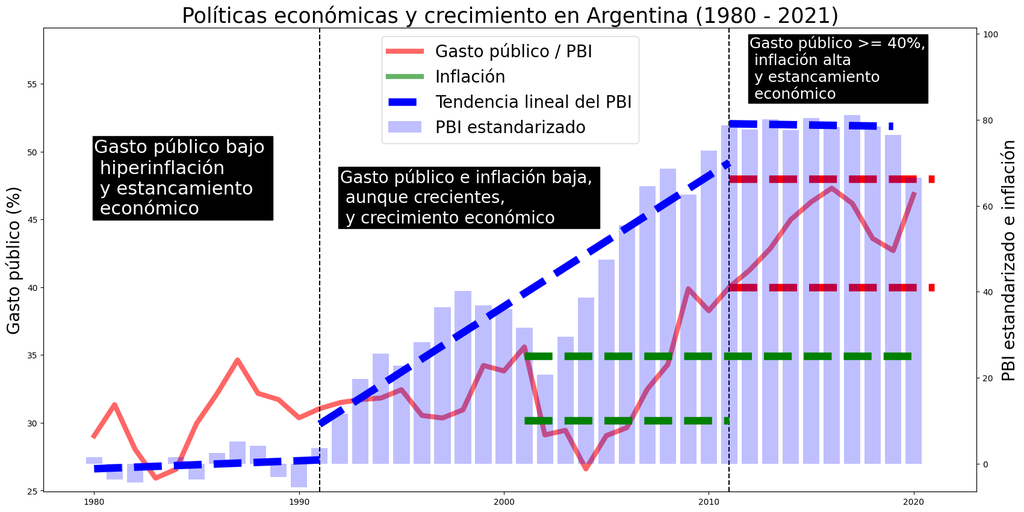

```python
public_exp_n_gdp = public_expenditure.merge(gdp_growth,left_index=True,right_index=True,how='left').merge(inflation_rate,left_index=True,right_index=True,how='left')
public_exp_n_gdp.index = public_exp_n_gdp.index.astype('int')

pub_exp_to_gdp, pub_exp_to_gdp_cum, inflation = public_exp_n_gdp.loc[:,'pubExpToGDP'], public_exp_n_gdp.loc[:,'gdpGrowth'].cumsum(), public_exp_n_gdp.loc[:,'inflation']
since_1st_period, since_2nd_period, since_3rd_period = 0, 11, 31
until_1st_period, until_2nd_period, until_3rd_period = 12, 32, 40
linewidth, linewidth_bounds, marketType = 6, 9, 'dashed'
p1 = np.poly1d(np.polyfit(x = pub_exp_to_gdp_cum.index[since_1st_period:until_1st_period].astype('float'), y = pub_exp_to_gdp_cum.iloc[since_1st_period:until_1st_period].astype('float'), deg = 1))
p2 = np.poly1d(np.polyfit(x = pub_exp_to_gdp_cum.index[since_2nd_period:until_2nd_period].astype('float'), y = pub_exp_to_gdp_cum.iloc[since_2nd_period:until_2nd_period].astype('float'), deg = 1))
p3 = np.poly1d(np.polyfit(x = pub_exp_to_gdp_cum.index[since_3rd_period:until_3rd_period].astype('float'), y = pub_exp_to_gdp_cum.iloc[since_3rd_period:until_3rd_period].astype('float'), deg = 1))

fig, ax1 = plt.subplots(figsize=(20,10))
ax2 = ax1.twinx()

ax1.plot(public_exp_n_gdp.index, pub_exp_to_gdp, color='r', linewidth = linewidth, label = 'Gasto público / PBI', alpha=.6)
ax2.bar(public_exp_n_gdp.index, pub_exp_to_gdp_cum, color='b', alpha = 0.25, label = 'PBI estandarizado')

ax2.plot(public_exp_n_gdp.index, np.where(inflation >= 100, 100, inflation), color = 'g', linewidth = linewidth, label = 'Inflación', alpha = .6)
ax2.plot(public_exp_n_gdp.index[since_1st_period : until_1st_period], p1(public_exp_n_gdp.index[since_1st_period : until_1st_period].astype('float')), color = 'b', linewidth = linewidth_bounds, linestyle = marketType, label = 'Tendencia lineal del PBI')
ax2.plot(public_exp_n_gdp.index[since_2nd_period : until_2nd_period], p2(public_exp_n_gdp.index[since_2nd_period : until_2nd_period].astype('float')), color = 'b', linewidth = linewidth_bounds, linestyle = marketType)
ax2.plot(public_exp_n_gdp.index[since_3rd_period : until_3rd_period], p3(public_exp_n_gdp.index[since_3rd_period : until_3rd_period].astype('float')), color = 'b', linewidth = linewidth_bounds, linestyle = marketType)

ax1.hlines(y = 40, xmin = 2011, xmax = 2021, color = 'red', linestyles = marketType, linewidth = linewidth_bounds)
ax1.hlines(y = 48, xmin = 2011, xmax = 2021, color = 'red', linestyles = marketType, linewidth = linewidth_bounds)
ax2.hlines(y = 25, xmin = 2001, xmax = 2020, color = 'green', linestyles = marketType, linewidth = linewidth_bounds)
ax2.hlines(y = 10, xmin = 2001, xmax = 2011, color = 'green', linestyles = marketType, linewidth = linewidth_bounds)
ax1.vlines(x = 1991, ymin = pub_exp_to_gdp.min() - 1, ymax = pub_exp_to_gdp.max() * 1.25, color = 'black', linestyles = marketType)
ax1.vlines(x = 2011, ymin = pub_exp_to_gdp.min() - 1, ymax = pub_exp_to_gdp.max() * 1.25, color = 'black', linestyles = marketType)

ax2.text(1980, 58, 'Gasto público bajo \n hiperinflación \n y estancamiento \n económico', color = 'white',
         bbox = dict(facecolor = 'black', edgecolor = 'black', pad = 2.0), fontsize = 22)
ax2.text(1992, 56, 'Gasto público e inflación baja, \n aunque crecientes, \n y crecimiento económico', color = 'white',
         bbox = dict(facecolor = 'black', edgecolor = 'black', pad = 2.0), fontsize = 20)
ax2.text(2012, 85, 'Gasto público >= 40%,\n inflación alta\n y estancamiento \n económico', color = 'white',
         bbox = dict(facecolor = 'black', edgecolor = 'black', pad = 2.0), fontsize = 18)

ax1.set_ylim(ymin = pub_exp_to_gdp.min() - 1, ymax = pub_exp_to_gdp.max() * 1.25)
ax2.set_ylim(ymin = pub_exp_to_gdp_cum.min() - 1, ymax = pub_exp_to_gdp_cum.max() * 1.25)
ax1.set_ylabel('Gasto público (%)', fontsize = 20)
ax2.set_ylabel('PBI estandarizado e inflación', fontsize = 20)

lines_1, labels_1 = ax1.get_legend_handles_labels()
lines_2, labels_2 = ax2.get_legend_handles_labels()
lines, labels = lines_1 + lines_2, labels_1 + labels_2
ax1.legend(lines, labels, loc = 'upper center', fontsize = 20)

plt.title('Políticas económicas y crecimiento en Argentina (1980 - 2021)', fontsize = 25)
plt.show()
```

Lo primero que se debe aclarar es que la serie que explica la inflación en los años en que la misma supera el valor de 100 se le asigna dicho valor para una mejor y más entendible visualización en el gráfico. También cabe aclarar que las líneas horizontales verdes y rojas buscan resaltar los niveles de inflación y de gasto público sobre el PBI en determinados periodos. También es importante destacar que este gráfico se circunscribe en el contexto de que la economía Argentina desde 1880 hasta las actualidad en las únicas décadas en las que no presentó crecimiento económico, sino que estancamiento, fueron en las décadas de 1980-1989 y 2010-2019, si consideramos las mismas con múltiplos de 10. La política económica de todo gobierno tiene dos partes: la política fiscal y la política monetaria. En la primera se decide cuánto se va a gastar y se estima cuánto se va a recaudar en cada periodo fiscal, y en la segunda se busca, a través de la institución de una autoridad monetaria independiente del gobierno (llamado Banco Central en la mayoría de los países del mundo), la estabilidad monetaria. En materia fiscal cuanto menor sea el gasto del sector público menores recursos necesitará recaudar y, por ende, mayor cantidad de recursos disponibles tendrá el sector privado para ampliar su capacidad productiva. En materia monetaria todos los bancos centrales buscan el equilibrio entre la oferta monetaria y la demanda monetaria para que no hayan cambios en los niveles precios (inflación) que complejicen la operatoria cotidiana de los distintos agentes de la economía doméstica. Este gráfico explica cómo durante la década de 1980-1989, a pesar de tener un gasto público bajo, los niveles sumamente altos de inflación no permitieron el desarrollo normal de la economía ahogándola en un estancamiento hasta llevarla a la mayor crisis económica de su historia hasta ese moemnto que fueron las hiperinflaciones de los añosd 1989 y 1990 en donde la inflación anual alcanzó los cuatro dígitos en ambos años. Posterior a esto, se siguió manteniendo un gasto público bajo y se implementó en esquema convertibilidad monetaria contra el dólar estadounidense que eliminó la inflación y permitió el crecimiento sostenido de la economía, salvo por el año 2002 en el que el país vivió su peor crisis económica debido al creciente gasto público y consecuente acumulación de deuda que no pudo ser honrada debidamente, pero gracias a: las políticas que se venían ejecutando; a un fuerte ajuste que se hizo del gasto público en el año 2002 y el crecimiento de los precios de las materias primas, que permitieron conseguir periodos de superávit fiscal y comercial, el país se recuperó rápido y creció durante el resto de la década 2000-2009, salvo en el año 2009 por una fuerte sequía, a expensas de un crecimiento constante y sostenido de la inflación y el gasto público que desde el año 2012 hasta la fecha no permitieron que el país vuelva a crecer y del que no se prevee horizonte alguno para que se recupere el crecimiento económico.

### Mercado Laboral (Cantidad)

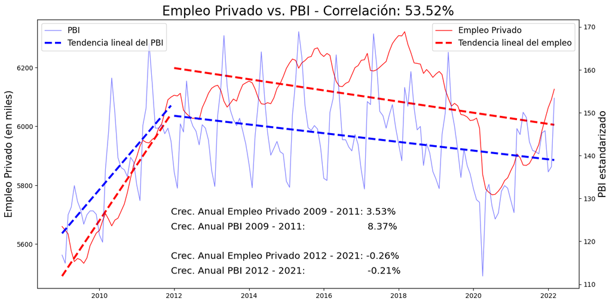

```python
gdp_n_jobs = pd.DataFrame(n_jobs_per_province['total']).merge(
    monthly_gdp,
    left_index = True,
    right_index = True,
    how = 'left')
correlation = round(np.corrcoef(
  gdp_n_jobs.iloc[:,0].astype('float'),
  gdp_n_jobs.iloc[:,1].astype('float'))[0][1] * 100, 2)

jpbs_mean_annual_growth_rate_2009_2011 = (gdp_n_jobs.loc['2011-01-01':'2011-12-01','total'].mean() / gdp_n_jobs.loc['2009-01-01':'2009-12-01','total'].mean() - 1) / (2011-2009)
jpbs_mean_annual_growth_rate_2012_2021 = (gdp_n_jobs.loc['2021-01-01':'2021-12-01','total'].mean() / gdp_n_jobs.loc['2012-01-01':'2012-12-01','total'].mean() - 1) / (2021-2011)
gpd_mean_annual_growth_rate_2009_2011 = (gdp_n_jobs.loc['2011-01-01':'2011-12-01','gdp'].mean() / gdp_n_jobs.loc['2009-01-01':'2009-12-01','gdp'].mean() - 1) / (2011-2009)
gdp_mean_annual_growth_rate_2012_2021 = (gdp_n_jobs.loc['2021-01-01':'2021-12-01','gdp'].mean() / gdp_n_jobs.loc['2012-01-01':'2012-12-01','gdp'].mean() - 1) / (2021-2011)

p1 = np.poly1d(np.polyfit(
  x = dates.date2num(gdp_n_jobs.loc['2009-01-01':'2011-12-01'].index),
  y = gdp_n_jobs.loc['2009-01-01':'2011-12-01','total'].values.astype('float'),
  deg = 1))
p2 = np.poly1d(np.polyfit(
  x = dates.date2num(gdp_n_jobs.loc['2012-01-01':'2022-03-01'].index),
  y = gdp_n_jobs.loc['2012-01-01':'2022-12-01','total'].values.astype('float'),
  deg = 1))
p3 = np.poly1d(np.polyfit(
  x = dates.date2num(gdp_n_jobs.loc['2009-01-01':'2011-12-01'].index),
  y = gdp_n_jobs.loc['2009-01-01':'2011-12-01','gdp'].values.astype('float'),
  deg = 1))
p4 = np.poly1d(np.polyfit(
  x = dates.date2num(gdp_n_jobs.loc['2012-01-01':'2022-03-01'].index),
  y = gdp_n_jobs.loc['2012-01-01':'2022-12-01','gdp'].values.astype('float'),
  deg = 1))

x_fit1 = np.linspace(
  dates.date2num(gdp_n_jobs.loc['2009-01-01':'2011-12-01'].index).min(),
  dates.date2num(gdp_n_jobs.loc['2009-01-01':'2011-12-01'].index).max())
x_fit2 = np.linspace(
  dates.date2num(gdp_n_jobs.loc['2012-01-01':'2022-03-01'].index).min(),
  dates.date2num(gdp_n_jobs.loc['2012-01-01':'2022-03-01'].index).max())

fig, ax1 = plt.subplots(figsize = (15, 7.5))
ax2 = ax1.twinx()

ax1.plot(gdp_n_jobs.index, gdp_n_jobs.iloc[:,0], c = 'r', label = 'Empleo Privado', linewidth = 1)
ax1.plot(dates.num2date(x_fit1), p1(x_fit1), c = 'r', label = 'Tendencia lineal del empleo', linewidth = 3, linestyle = marketType)
ax1.plot(dates.num2date(x_fit2), p2(x_fit2), c = 'r', linewidth = 3, linestyle = marketType)
ax2.plot(gdp_n_jobs.index, gdp_n_jobs.iloc[:,1], c = 'b', alpha = 0.5, label = 'PBI', linewidth = 1)
ax2.plot(dates.num2date(x_fit1), p3(x_fit1), c = 'b', label = 'Tendencia lineal del PBI', linewidth = 3, linestyle = marketType)
ax2.plot(dates.num2date(x_fit2), p4(x_fit2), c = 'b', linewidth = 3, linestyle = marketType)

ax1.text(x_fit1[-1], 5700, f'Crec. Anual Empleo Privado 2009 - 2011: {round(jpbs_mean_annual_growth_rate_2009_2011 * 100, 2)}%', fontsize = 'x-large')
ax1.text(x_fit1[-1], 5650, f'Crec. Anual PBI 2009 - 2011:                     {round(gpd_mean_annual_growth_rate_2009_2011 * 100, 2)}%', fontsize = 'x-large')
ax1.text(x_fit1[-1], 5550, f'Crec. Anual Empleo Privado 2012 - 2021: {round(jpbs_mean_annual_growth_rate_2012_2021 * 100, 2)}%', fontsize = 'x-large')
ax1.text(x_fit1[-1], 5500, f'Crec. Anual PBI 2012 - 2021:                     {round(gdp_mean_annual_growth_rate_2012_2021 * 100, 2)}%', fontsize = 'x-large')

ax1.set_ylabel('Empleo Privado (en miles)', fontsize = 15)
ax2.set_ylabel('PBI estandarizado', fontsize = 15)
ax1.legend(loc='upper right', fontsize = 12.5)
ax2.legend(loc='upper left', fontsize = 12.5)

plt.title(f'Empleo Privado vs. PBI - Correlación: {correlation}%', fontsize = 20)
plt.show()
```

Este gráfico nos muestra el efecto directo que tiene la falta de crecimiento económico sobre el empleo. Es importante resaltar especialmente el efecto sobre el empleo privado porque es aquél que financia el gasto publico y representa la mayor proporción de los distintos tipos de empleo (ver próximo gráfico). Acá claramente podemos apreciar cómo durante el periodo 2009-2011 el crecimiento económico permitía la generación de empleo privado y que posteriormente a ello hasta la actualidad la economía y el empleo privado se encuentran estancados. Esto tiene como consecuencia una degradación de la calidad del empleo ya que este no acompaña el crecimiento demográfico, lo que tiene como consecuencia que la parte de la población que no se pueda incorporar a la economía formal o sean reemplazados dentro de la misma, o bien degraden su calidad de empleo, deban incurrir a la informalidad, al auxilio del estado o a una combinación de las mismas para cubrir sus necesidades básicas.

### Mercado Laboral por Modalidad (Cantidad)

[figure not shown]

```python
population_2010, population_2022 = 40117096, 47327407
annual_growth = (population_2022 / population_2010) ** (1 / (2022 - 2010)) - 1
population_growth = round((population_2022 / (population_2010 * (1 + annual_growth) ** 2) - 1) * 100, 2)

columns = n_jobs_per_type.columns.drop('Total')
columns = pd.concat([n_jobs_per_type[col] / n_jobs_per_type['Total'] for col in columns], axis = 1, keys = columns)

firstRow, lastRow, linewidth = n_jobs_per_type.index[0], n_jobs_per_type.index[-1], 3
plt.figure(figsize=(20,10))

for col in n_jobs_per_type.columns:
  growth_rate = round((n_jobs_per_type.loc[lastRow, col] / n_jobs_per_type.loc[firstRow, col] - 1) * 100, 2)
  plt.plot(
    pd.to_datetime(n_jobs_per_type.index),
    n_jobs_per_type[col].pct_change().cumsum(),
    label = f'{col} - Crec. Acum.: {growth_rate}%',
    linewidth = linewidth)
plt.scatter(pd.to_datetime(n_jobs_per_type.index), n_jobs_per_type['Total'].pct_change().cumsum(), label = f'Total - Crec. Acum.: {g}%', color = 'black')
plt.scatter(pd.to_datetime(n_jobs_per_type.index), pd.Series(np.linspace(population_2010, population_2022, len(n_jobs_per_type.index))).pct_change().cumsum(), label = f'Población - Crec. Acum.: {population_growth}%', color = 'black', s = 1)

plt.hlines(y = 0, xmin = n_jobs_per_type.index[0], xmax =  n_jobs_per_type.index[-1], linestyles = 'dotted', color = 'black')
plt.legend(loc = 'upper left', frameon = False, fontsize = 15)
plt.ylabel("Crecimiento relativo acumulado", fontsize = 20)
plt.title('Crecimiento relativo acumulado de las distintas modalidades de empleo en Argentina (2012 - 2021)', fontsize = 20)
plt.show()
```

La primera reflexión que nos brinda este gráfico es que el empleo acompañó el crecimiento demográfico pero a expensas de una reducción en su calidad. En argentina existen distintas figuras legales para categorizar a la fuerza laboral. A los conocidos empleados públicos y privados en relación de dependencia, se le suman las siguiente categorías: 1. Autónomo: empleado independendiente de mayor capacidad de ingresos. 2. Monotributista: empleado independiente de menor capacidad de ingresos que un autónomo. 3. Monotributista social: monotributista que se encuentra dentro de las categorías del monotributo que menor capacidad de ingresos tiene. 4. Empleo en casas particulares: son todos aquellos que realizan tareas domésticas. Una segunda y más importante lectura es que el crecimiento del empleo privado y de los autónomos fue nulo. El empleo privado es aquél que mayor valor genera de todos y los trabajadores autónomos representan a las futuras empresas que puede tener el país. A expensas de esto tanto los monotributistas, empleados públicos y empleados domésticos crecieron en promedio un 30% en este periodo y los monotributistas sociales, que son aquellos trabajadores que menor valor aportan a la economía, crecieron alrededor del 160%. Esto permite concluir en que hubo una clara caída en la calidad de vida de los argentinos durante el periodo en cuestión.

```python
x, y = PrettyTable(), PrettyTable()
x.title, y.title = 'Proporción de empleados por tipo de empleo en 01-2012', 'Proporción de empleados por tipo de empleo en 03-2022'
x.field_names, y.field_names = ["Tipo de empleo", "Proporción"], ["Tipo de empleo", "Proporción"]
for i in range(cols.shape[1]):
  x.add_row([columns.columns[i],round(columns.iloc[0,i]*100,2)])
  y.add_row([columns.columns[i],round(columns.iloc[-1,i]*100,2)])
x.sortby, y.sortby = 'Proporción', 'Proporción'
x.reversesort, y.reversesort = True, True
print(x,'\n',y)
```

[output not shown]

### Mercado Laboral (Precio)

[figure not shown]

```python
sal_annual_growth = salaries['PRIVATE_SECTOR_SALARY'].reset_index()
sal_annual_growth['YEAR'] = pd.to_datetime(sal_annual_growth['DATE']).dt.year
years = sal_annual_growth.groupby('YEAR')['YEAR'].count()[sal_annual_growth.groupby('YEAR')['YEAR'].count() == 12].index
sal_annual_growth = sal_annual_growth[sal_annual_growth['YEAR'].isin(years)]
sal_annual_growth = sal_annual_growth.groupby('YEAR')['PRIVATE_SECTOR_SALARY'].mean().pct_change().dropna().reset_index()

real_salary = sal_annual_growth.merge(
    inflation_rate,
    left_on = 'YEAR',
    right_index = True,
    how = 'left').set_index('YEAR')
real_salary.loc['2021','inflation'] = 50.9
real_salary['inflation'] = real_salary['inflation'] / 100
real_salary = (1 + real_salary.cumsum()) * 100
real_salary['real_salary_growth'] = (1 + real_salary['PRIVATE_SECTOR_SALARY']) / (1 + real_salary['inflation']) - 1

gdp_yearly = monthly_gdp.reset_index()
gdp_yearly['YEAR'] = gdp_yearly['index'].dt.year
years = gdp_yearly.groupby('YEAR')['YEAR'].count()[gdp_yearly.groupby('YEAR')['YEAR'].count() == 12].index
gdp_yearly = gdp_yearly[gdp_yearly['YEAR'].isin(years)]
gdp_yearly = gdp_yearly.groupby('YEAR')['gdp'].mean().pct_change().dropna()

real_salary = real_salary.merge(gdp_yearly, left_index = True, right_index = True, how = 'left').dropna()

fig, ax1 = plt.subplots(figsize = (20, 10))
ax2 = ax1.twinx()

ax1.plot(real_salary.index,real_salary['real_salary_growth'], color = 'b', label = 'Variación del Salario Real', linewidth = 3)
ax2.plot(real_salary.index,real_salary['gdp'], color = 'g', label = 'PBI estandarizado', alpha = 0.35, linewidth = 3)
ax1.hlines(y = 0, xmin = real_salary.index[0], xmax = real_salary.index[-1], colors = 'r', linewidth = 3, linestyles = 'dashed')
ax1.set_ylabel("Variación salarial", fontsize = 20)
ax2.set_ylabel("PBI estandarizado", fontsize = 20)

lines_1, labels_1 = ax1.get_legend_handles_labels()
lines_2, labels_2 = ax2.get_legend_handles_labels()
lines, labels = lines_1 + lines_2, labels_1 + labels_2
ax1.legend(lines, labels, loc = 'upper left', fontsize = 15)

plt.title("Evolución del salario real en Argentina (2012 - 2021)", fontsize = 25)
plt.show()
```